# PM2.5 on the London Underground

4 March 2019

## Why me?

- Environmental Research Group
- PhD
- The London Hybrid Exposure Model
- A Game of Thrones

[figure not shown]

## Why, and why now?

- Exposure to particles on subway systems > important
- Seaton et al 2005, but …
  - Tox. mechanisms
  - Susceptible populations
  - Analytical techniques

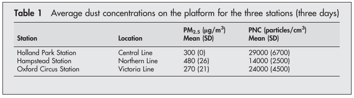

## What we tried to do?

- Measure variations in PM<sub>2.5</sub> between lines and stations
- Characterise the chemical composition
- Calculate calibration factors for optical instruments
- Provide a spatially resolved dataset for future analysis

[figure not shown]

## Campaign One

- COPD Study
- 22 journeys alternating between Oxford Street / Hyde Park
- TSI AM510 SidePak for PM2.5
- Philips Aerasense for ultrafine particle number and mean particle diameter

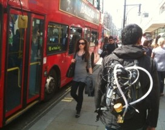

## Campaign Two

- Same equipment
- 31 hours
- All lines
- 89% of stations (NE Central, SW Piccadilly)

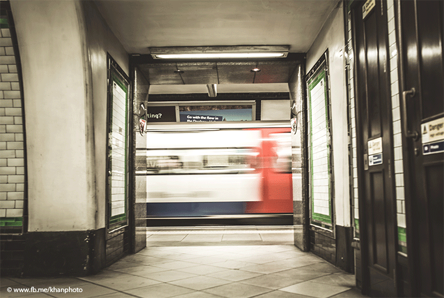

## Calibration

- Hampstead Station platform v. overground
- One month
- Filters v. TSI AM510 SidePak

[figure not shown]

## Passenger-weighted stations

- 2015 tap in/tap out, Underground performance report
- Annual in/out for each station
- Mean PM<sub>2.5</sub> measured at each station
- Passenger rank * air quality rank = passenger-weighted ranking

[figure not shown]

## Spatial representation of the tube

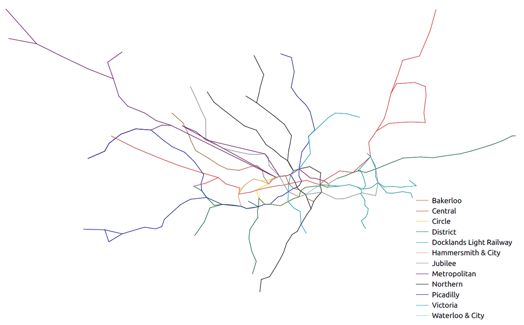

## What next?

## The end

*Public health risks from respirable particles on the 'London Underground' metro network*

Smith, J.D., Green, D., Loxham, M. Priestman, M., Tremper, A., Mudway, I., Fuller, G., Nicolosi, E., Barratt, B.M.

james.d.smith@kcl.ac.uk

[TheRealJimShady](http://twitter.com/therealjimshady)